# Банки — Сегментация пользователей по потреблению

**Заказчиком данной работы является менеджер регионального банка "Метанпромбанк", который располагается в Ярославле и областных городах: Ростов Великий и Рыбинск. Задачей данного продуктового исследования является анализ клиентов банка и сегментация пользователей по количеству потребляемых продуктов с целью выявления сегментов, склонных к оттоку, для выработки оптимальных стратегий удержания клиентов из каждого сегмента. Результатами исследования будут являться рекомендации по удержанию клиентов для каждого сегмента.**

## Загрузка данных, подготовка их к анализу

### Загрузка библиотек

Мой основной инструмент — `pandas`. Я подключаю эту библиотеку. Также подключаю библиотеки `seaborn`, `matplotlib.pyplot`, `StandardScaler из sklearn.preprocessing`, `dendrogram и linkage из scipy.cluster.hierarchy`, `sklearn.cluster`, `scipy`, `numpy` и `math`. Они потребуются для проведения моего исследования.

Также дополнительно отключу предупреждения - библиотека `warnings`.

```python
import pandas as pd             # импорт библиотеки pandas
import seaborn as sns
import matplotlib.pyplot as plt
from sklearn.preprocessing import StandardScaler
from sklearn.preprocessing import LabelEncoder
from scipy.cluster.hierarchy import dendrogram, linkage
from sklearn.cluster import KMeans
from scipy import stats as st
import numpy as np
import math as mth

import warnings as wg

wg.filterwarnings('ignore')
```

### Загрузка и описание данных

```python
try:
    data = pd.read_csv('/Users/a4128/Documents/Final_project/bank_dataset.csv') # локальный путь
except:
    data = pd.read_csv('/datasets/bank_dataset.csv') # серверный путь

display(data.head())
print()
data.info()
```

|  | userid | score | City | Gender | Age | Objects | Balance | Products | CreditCard | Loyalty | estimated_salary | Churn |
| --- | --- | --- | --- | --- | --- | --- | --- | --- | --- | --- | --- | --- |
| 0 | 15677338 | 619 | Ярославль | Ж | 42 | 2 | NaN | 1 | 1 | 1 | 101348.88 | 1 |
| 1 | 15690047 | 608 | Рыбинск | Ж | 41 | 1 | 83807.86 | 1 | 0 | 1 | 112542.58 | 0 |
| 2 | 15662040 | 502 | Ярославль | Ж | 42 | 8 | 159660.80 | 3 | 1 | 0 | 113931.57 | 1 |
| 3 | 15744090 | 699 | Ярославль | Ж | 39 | 1 | NaN | 2 | 0 | 0 | 93826.63 | 0 |
| 4 | 15780624 | 850 | Рыбинск | Ж | 43 | 2 | 125510.82 | 1 | 1 | 1 | 79084.10 | 0 |

```
<class 'pandas.core.frame.DataFrame'>
RangeIndex: 10000 entries, 0 to 9999
Data columns (total 12 columns):
 #   Column            Non-Null Count  Dtype
---  ------            --------------  -----
 0   userid            10000 non-null  int64
 1   score             10000 non-null  int64
 2   City              10000 non-null  object
 3   Gender            10000 non-null  object
 4   Age               10000 non-null  int64
 5   Objects           10000 non-null  int64
 6   Balance           6383 non-null   float64
 7   Products          10000 non-null  int64
 8   CreditCard        10000 non-null  int64
 9   Loyalty           10000 non-null  int64
 10  estimated_salary  10000 non-null  float64
 11  Churn             10000 non-null  int64
dtypes: float64(2), int64(8), object(2)
memory usage: 937.6+ KB
```

### Выводы по разделу

Согласно документации к данным:

- `userid` — идентификатор пользователя,
- `score` — баллы кредитного скоринга,
- `City` — город,
- `Gender` — пол,
- `Age` — возраст,
- `Objects` — количество объектов в собственности,
- `Balance` — баланс на счёте,
- `Products` — количество продуктов, которыми пользуется клиент,
- `CreditCard` — есть ли кредитная карта,
- `Loyalty` — активный клиент,
- `estimated_salary` — заработная плата клиента,
- `Churn` — факт оттока.

Выявлено:

- в названиях колонок (`userid`, `City`, `Gender`, `Age`, `Objects`, `Balance`, `Products`, `CreditCard`, `Loyalty`, `Churn`) присутствует нарушения стиля, а именно: отсутствие змеиного регистра и наличие заглавных букв;
- количество значений в столбце `Balance` отличается от количества строк, из чего можно сделать вывод, что в данных есть пропущенные значения);
- все типы данных соответствуют логике.

## Предобработка данных

### Восстановление стиля названий столбцов

Для начала восстановлю стиль названий для тех колонок, где обнаружены нарушения, а именно составное имя переменной написано с использованием заглавных букв, а также использую змеиный регистр для названий колонок `userid` и `creditcard`:

```python
data.columns = data.columns.str.lower()
data = data.rename(columns={'userid': 'user_id',
                            'creditcard': 'credit_card'})
# проверка
data.columns
```

```
Index(['user_id', 'score', 'city', 'gender', 'age', 'objects', 'balance',
       'products', 'credit_card', 'loyalty', 'estimated_salary', 'churn'],
      dtype='object')
```

### Проверка данных на дубликаты

```python
print('Количество явных дубликатов в датафрейме:', data.duplicated().sum())
```

```
Количество явных дубликатов в датафрейме: 0
```

### Поиск и обработка пропущенных значений

```python
print('Всего пропусков в столбце balance -', data['balance'].isna().sum())
print('Доля пропущенных значений составляет {:.1%}'.format(len(data.query('balance.isna()')) / len(data)))
```

```
Всего пропусков в столбце balance - 3617
Доля пропущенных значений составляет 36.2%
```

Можно предположить, что существует определённая закономерность появления такого большого количества пропущенных значений. Попробую ее определить. Зависит ли появление пропусков, например, от города, у пользователей определенных возрастов и пр. Для этого выделю `Series` с отсутствующими значениями и применю группировку по каждому признаку.

```python
data['balance_mis'] = data['balance'].isna()
col = ['age', 'city', 'objects', 'products', 'credit_card', 'loyalty', 'churn']

for element in col:
    print('Проверка гипотезы о зависимости появления пропусков от:', element)
    print(data.groupby(element)['balance_mis'].mean().sort_values(ascending=False).round(3))
    print()
```

```
Проверка гипотезы о зависимости появления пропусков от: age
age
88    1.000
85    1.000
82    1.000
80    1.000
81    0.750
      ...
78    0.200
76    0.091
83    0.000
84    0.000
92    0.000
Name: balance_mis, Length: 70, dtype: float64

Проверка гипотезы о зависимости появления пропусков от: city
city
Рыбинск           0.484
Ярославль         0.482
Ростов Великий    0.000
Name: balance_mis, dtype: float64

Проверка гипотезы о зависимости появления пропусков от: objects
objects
6     0.380
7     0.375
4     0.373
5     0.370
9     0.366
2     0.365
10    0.363
8     0.354
3     0.349
1     0.337
0     0.332
Name: balance_mis, dtype: float64

Проверка гипотезы о зависимости появления пропусков от: products
products
2    0.566
3    0.368
4    0.233
1    0.178
Name: balance_mis, dtype: float64

Проверка гипотезы о зависимости появления пропусков от: credit_card
credit_card
1    0.367
0    0.348
Name: balance_mis, dtype: float64

Проверка гипотезы о зависимости появления пропусков от: loyalty
loyalty
1    0.364
0    0.360
Name: balance_mis, dtype: float64

Проверка гипотезы о зависимости появления пропусков от: churn
churn
0    0.391
1    0.245
Name: balance_mis, dtype: float64
```

Из полученных таблиц видно, что распределение долей пропущенных значений в группах по количеству объектов в собственности, а также по активности, наличию кредитных карт и факту оттока из банка - более или менее равномерно. Однако можно заметить, что в Ростове Великом пропусков нет совсем, а в Ярославле и Рыбинске поровну, также можно увидеть, что большая доля пропусков у пользователей пожилого поколения. В таблице, где показана зависимость количества пропусков от количества продуктов банка, можно заметить следующее: больше, чем для половины пользователей с 2 продуктами не указан баланс. Попробую сгруппировать и посмотреть.

```python
data_test = data.loc[data['city'] != 'Ростов Великий']
col = ['age', 'products']

for element in col:
    print('Проверка гипотезы о зависимости появления пропусков от:', element)
    print(data_test.groupby(element)['balance_mis'].mean().sort_values(ascending=False).round(3))
    print()
```

```
Проверка гипотезы о зависимости появления пропусков от: age
age
81    1.000
88    1.000
85    1.000
82    1.000
80    1.000
      ...
63    0.294
78    0.250
76    0.125
84    0.000
92    0.000
Name: balance_mis, Length: 69, dtype: float64

Проверка гипотезы о зависимости появления пропусков от: products
products
2    0.732
3    0.576
4    0.389
1    0.242
Name: balance_mis, dtype: float64
```

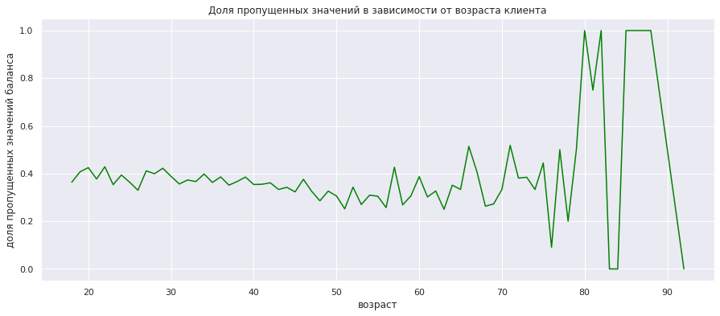

```python
data_test = data.pivot_table(index='age', values='balance_mis', aggfunc='mean')
data_test.plot(grid=True,
               title='Доля пропущенных значений в зависимости от возраста клиента',
               figsize=(15, 6),
               color='green',
               legend=None)
plt.xlabel('возраст')
plt.ylabel('доля пропущенных значений баланса');
```

Из полученного графика видно, что пропуски характерны более для пожилых клиентов банка. Однако нельзя чётко выявить зависимость появления пропуской из-за какого-то фактора.

### Выводы по разделу

На этапе предварительной обработки данных:

- восстановлен стиль названий для тех колонок, где обнаружены нарушения;
- дубликатов в данных не выявлено;
- обнаружены пропущенные значения в столбце `balance`, пропусков более 36%;
- в Ростове Великом пропуски в данных не обнаружены, только в Ярославле и Рыбинске;
- пропуски в данных в основном характерны для клиентов пожилого поколения;
- более всего пропусков у пользователей 2 продуктов.

По пропущенным значениям: возможно, в Ярославле и Рыбинске произошел технический сбой, который привёл к потере данных, возможно, информация просто была не внесена (что маловероятно, т.к. в Ростове Великом 100% заполненных данных, что говорит о том, что эта информация скорее всего обязательна к заполнению). Делаю вывод, что информация просто была утеряна в связи с каким-то фактором, вне зависимости от клиента и его профиля.

Т.к. доля пропущенных значений в столбце `balance` очень велика - более 36%, исключать такое количество записей или заполнять по принципу среднего или медианы по какому-либо принципу считаю нецелесообразным, т.к. это может исказить результаты статистических тестов.

## Исследовательский анализ данных (EDA)

### Предварительная оценка корректности данных

```python
display(round(data.drop('user_id', axis=1).describe(percentiles = [], include = ['float', 'int'])))
```

|  | score | age | objects | balance | products | credit_card | loyalty | estimated_salary | churn |
| --- | --- | --- | --- | --- | --- | --- | --- | --- | --- |
| count | 10000.0 | 10000.0 | 10000.0 | 6383.0 | 10000.0 | 10000.0 | 10000.0 | 10000.0 | 10000.0 |
| mean | 651.0 | 39.0 | 5.0 | 119827.0 | 2.0 | 1.0 | 1.0 | 100090.0 | 0.0 |
| std | 97.0 | 10.0 | 3.0 | 30095.0 | 1.0 | 0.0 | 0.0 | 57510.0 | 0.0 |
| min | 350.0 | 18.0 | 0.0 | 3769.0 | 1.0 | 0.0 | 0.0 | 12.0 | 0.0 |
| 50% | 652.0 | 37.0 | 5.0 | 119840.0 | 1.0 | 1.0 | 1.0 | 100194.0 | 0.0 |
| max | 850.0 | 92.0 | 10.0 | 250898.0 | 4.0 | 1.0 | 1.0 | 199992.0 | 1.0 |

```python
data.pivot_table(index='city', columns='gender', values='user_id', aggfunc='count')
```

| gender city | Ж | М |
| --- | --- | --- |
| Ростов Великий | 1193 | 1316 |
| Рыбинск | 1089 | 1388 |
| Ярославль | 2261 | 2753 |

По результатам полученной таблицы и полученных ранее данных можно сказать следующее:

- в выборке присутствуют пользователи обоих полов (мужчины и женщины) из 3 городов;
- баллы кредитного скоринга распределены в диапазоне 350 - 850;
- средний возраст клиента - 39 лет, минимальный возраст - 18, максимальный - 92 года;
- объектов собственности от 0 до 10;
- в среднем на балансе у клиента - около 120т.р., минимум 3800р., максимум 250т.р.;
- продуктов банка от 1 до 4;
- кредитные карты, в основном, у пользователей есть;
- преобладают активные клиенты;
- средняя з/п клиента - 100т.р., минимум 12р., максимум - 200т.р..

### Преобразование категориальных переменных

Для будущих построений и исследования зависимостей необходимо провести замену категориальных переменных количественными. Проверю, какие есть категориальные переменные и какие значения они принимают:

```python
print(data['city'].value_counts())
print()
print(data['gender'].value_counts())
```

```
Ярославль         5014
Ростов Великий    2509
Рыбинск           2477
Name: city, dtype: int64

М    5457
Ж    4543
Name: gender, dtype: int64
```

Для обработки данных проведу замену категориальных переменных в столбцах `city` и `gender` с использованием `One Hot Encoding` (представление одного категориального поля в множество бинарных полей). Выбор этого метода обработки обусловлен тем, что признаков всего 2 и уникальных значений не так много (2 и 3), поэтому преобразование не сильно повлияет на размер исследуемого датафрейма. Одним из лучших преимуществ этого кодирования является то, что оно представляет категориальные данные для большей выразительности и не существует порядкового отношения.

Буду использовать `get_dummies`.

```python
columns = ['city', 'gender']

for element in columns:
    one_hot = pd.get_dummies(data[element])
    data = data.drop(element, axis=1)
    data = data.join(one_hot)

data
```

|  | user_id | score | age | objects | balance | products | credit_card | loyalty | estimated_salary | churn | balance_mis | Ростов Великий | Рыбинск | Ярославль | Ж | М |
| --- | --- | --- | --- | --- | --- | --- | --- | --- | --- | --- | --- | --- | --- | --- | --- | --- |
| 0 | 15677338 | 619 | 42 | 2 | NaN | 1 | 1 | 1 | 101348.88 | 1 | True | 0 | 0 | 1 | 1 | 0 |
| 1 | 15690047 | 608 | 41 | 1 | 83807.86 | 1 | 0 | 1 | 112542.58 | 0 | False | 0 | 1 | 0 | 1 | 0 |
| 2 | 15662040 | 502 | 42 | 8 | 159660.80 | 3 | 1 | 0 | 113931.57 | 1 | False | 0 | 0 | 1 | 1 | 0 |
| 3 | 15744090 | 699 | 39 | 1 | NaN | 2 | 0 | 0 | 93826.63 | 0 | True | 0 | 0 | 1 | 1 | 0 |
| 4 | 15780624 | 850 | 43 | 2 | 125510.82 | 1 | 1 | 1 | 79084.10 | 0 | False | 0 | 1 | 0 | 1 | 0 |
| ... | ... | ... | ... | ... | ... | ... | ... | ... | ... | ... | ... | ... | ... | ... | ... | ... |
| 9995 | 15648965 | 771 | 39 | 5 | NaN | 2 | 1 | 0 | 96270.64 | 0 | True | 0 | 0 | 1 | 0 | 1 |
| 9996 | 15612628 | 516 | 35 | 10 | 57369.61 | 1 | 1 | 1 | 101699.77 | 0 | False | 0 | 0 | 1 | 0 | 1 |
| 9997 | 15627268 | 709 | 36 | 7 | NaN | 1 | 0 | 1 | 42085.58 | 1 | True | 0 | 0 | 1 | 1 | 0 |
| 9998 | 15725091 | 772 | 42 | 3 | 75075.31 | 2 | 1 | 0 | 92888.52 | 1 | False | 1 | 0 | 0 | 0 | 1 |
| 9999 | 15671055 | 792 | 28 | 4 | 130142.79 | 1 | 1 | 0 | 38190.78 | 0 | False | 0 | 0 | 1 | 1 | 0 |

10000 rows × 16 columns

После проведения замены необходима проверка, не указано ли у одного и того же пользователя несколько городов и полов, у всех ли пользователей указан пол и город.

```python
# проверка
print('Количество пользователей с указанием нескольких городов:',
      data.loc[(data['Ростов Великий'] == 1) & (data['Рыбинск'] == 1)
              |(data['Ростов Великий'] == 1) & (data['Ярославль'] == 1)
              |(data['Рыбинск'] == 1) & (data['Ярославль'] == 1)]['user_id'].count())
print()
print('Количество пользователей без указания города:',
      data.loc[(data['Ростов Великий'] == 0) & (data['Рыбинск'] == 0) & (data['Ярославль'] == 0)]['user_id'].count())
print()
print('Количество пользователей с указанием обоих полов или без указания пола:',
      data.loc[(data['Ж'] == 1) & (data['М'] == 1)
              |(data['Ж'] == 0) & (data['М'] == 0)]['user_id'].count())
```

```
Количество пользователей с указанием нескольких городов: 0

Количество пользователей без указания города: 0

Количество пользователей с указанием обоих полов или без указания пола: 0
```

### Оценка аномалий/выбросов в данных

Проверке на выбросы подлежат следующие признаки:

- `score` - баллы кредитного скоринга;
- `balance` - баланс на счёте;
- `estimated_salary` - заработная плата клиента.

|  | score | balance | estimated_salary |
| --- | --- | --- | --- |
| count | 10000.00 | 6383.00 | 10000.00 |
| mean | 650.53 | 119827.49 | 100090.24 |
| std | 96.65 | 30095.06 | 57510.49 |
| min | 350.00 | 3768.69 | 11.58 |
| 25% | 584.00 | 100181.98 | 51002.11 |
| 50% | 652.00 | 119839.69 | 100193.92 |
| 75% | 718.00 | 139512.29 | 149388.25 |
| max | 850.00 | 250898.09 | 199992.48 |

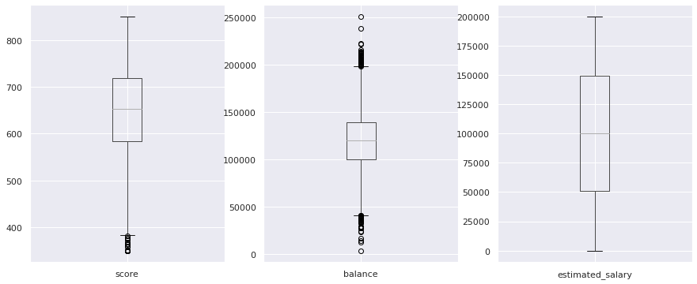

```python
display(data[['score', 'balance', 'estimated_salary']].describe().round(2))
columns = ['score', 'balance', 'estimated_salary']

i = 0

fig, axes = plt.subplots(1, 3, figsize=(15,6))
for element in columns:
    data.boxplot(column=element, ax=axes[i])
    i += 1
plt.show();
```

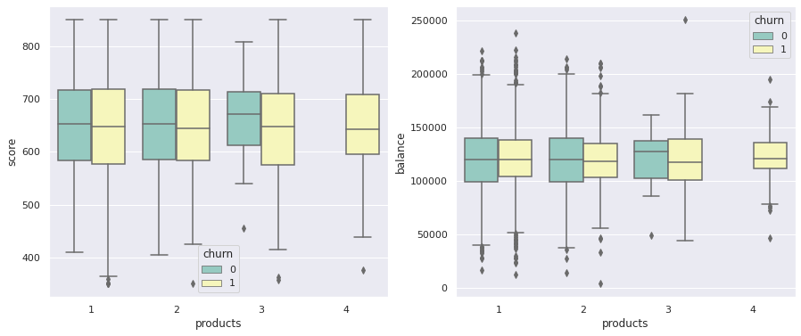

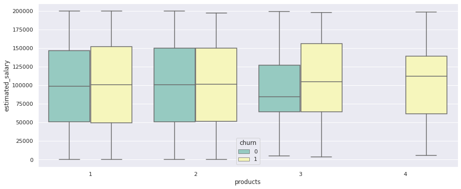

```python
# проверка на выбросы в разрезе оттока клиентов
columns = ['score', 'balance', 'estimated_salary']
fig, axes = plt.subplots(1, 2, figsize=(15,6))

plt.figure(figsize=(15, 6))
sns.boxplot(x='products', y='score', hue='churn', data=data, palette='Set3', ax=axes[0])

sns.boxplot(x='products', y='balance', hue='churn', data=data, palette='Set3', ax=axes[1])

sns.boxplot(x='products', y='estimated_salary', hue='churn', data=data, palette='Set3')

plt.show();
```

Исходя из полученных графиков, можно сказать, что данные по заработной плате адекватны, в значениях кредитного скоринга встречаются аномально низкие значения, а значения баланса встречаются как аномально низкие, так и аномально высокие. Т.к. по диаграммам размаха видно, что медиана не стремится к длинному хвосту высоких значений, выбросов немного, поэтому я не буду обрабатывать (удалять/заменять) эти выбросы, считая, что моя модель будет к ним устойчива.

Т.к. признак зарплата клиента не имеет ни одного выброса, что настораживает чистотой данных, я построю гистограмму распределения этого признака.

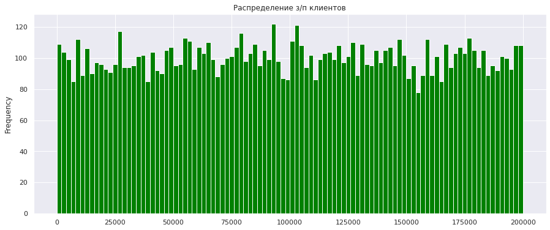

```python
data['estimated_salary'].plot(kind='hist',
                              bins=100,
                              grid=True,
                              figsize=(15,6),
                              color='green',
                              title='Распределение з/п клиентов');
```

Можно заметить, что распределение признака `зарплата клиента` имеет вид равномерного, это может указывать на следующее:

- данная выборка является неполной;
- з/п заполнена автоматически в качестве простого априорного допущения.

Проверю также, на что могут влиять баллы кредитного скоринга. Применю категоризацию по 25 и 75 процентилю (данные возьму из таблицы `describe` и построенных ранее диаграмм размаха):

```python
# определение категории в соответствии с кредитным скорингом
def categorize(score):
    if score < 584:
        return 'низкий'
    if score > 718:
        return 'высокий'
    return 'средний'

data['score_category'] = data['score'].apply(categorize) # запись категории в столбец

print('Количество записей в категориях:')
print(data['score_category'].value_counts())
print()
print('Доля в % от всех записей:')
print(round(data['score_category'].value_counts() / len(data) * 100))
```

```
Количество записей в категориях:
средний    5046
низкий     2491
высокий    2463
Name: score_category, dtype: int64

Доля в % от всех записей:
средний    50.0
низкий     25.0
высокий    25.0
Name: score_category, dtype: float64
```

Сгруппирую по категориям и оценю средние значения признаков для нахождения различий между этими категориями:

```python
display(data.drop(['user_id', 'score'], axis=1).pivot_table(index='score_category', aggfunc='mean').round(2))
data = data.drop(['score_category', 'balance_mis'], axis=1)
```

| score_category | age | balance | balance_mis | churn | credit_card | estimated_salary | loyalty | objects | products | Ж | М | Ростов Великий | Рыбинск | Ярославль |
| --- | --- | --- | --- | --- | --- | --- | --- | --- | --- | --- | --- | --- | --- | --- |
| высокий | 38.95 | 119600.57 | 0.36 | 0.20 | 0.70 | 100865.80 | 0.52 | 5.02 | 1.53 | 0.45 | 0.55 | 0.26 | 0.24 | 0.49 |
| низкий | 38.81 | 120269.85 | 0.37 | 0.22 | 0.70 | 100254.80 | 0.49 | 4.97 | 1.51 | 0.45 | 0.55 | 0.25 | 0.24 | 0.52 |
| средний | 38.96 | 119722.79 | 0.36 | 0.20 | 0.71 | 99630.45 | 0.52 | 5.03 | 1.54 | 0.46 | 0.54 | 0.25 | 0.26 | 0.50 |

Из результатов полученной таблицы можно сделать вывод о том, что клиентов с высоким и низким скором ничего не различает.

## Сегментация пользователей на основе данных о количестве потребляемых продуктов

### Выявление профиля клиента банка в зависимости от количества продуктов

Для получения общего представления о клиенте, который пользуется продуктами банка, необходимо сгруппировать всех клиентов по количеству продутов банка и посмотреть среднее значение признаков.

```python
pd.pivot_table(data.drop('user_id', axis=1), index='products', aggfunc='mean').round(2)
```

| products | age | balance | churn | credit_card | estimated_salary | loyalty | objects | score | Ж | М | Ростов Великий | Рыбинск | Ярославль |
| --- | --- | --- | --- | --- | --- | --- | --- | --- | --- | --- | --- | --- | --- |
| 1 | 39.67 | 119894.16 | 0.28 | 0.70 | 99487.26 | 0.50 | 4.97 | 649.12 | 0.45 | 0.55 | 0.27 | 0.24 | 0.49 |
| 2 | 37.75 | 119660.94 | 0.08 | 0.71 | 100452.01 | 0.53 | 5.05 | 652.19 | 0.45 | 0.55 | 0.23 | 0.26 | 0.52 |
| 3 | 43.20 | 119475.69 | 0.83 | 0.71 | 104318.13 | 0.42 | 5.00 | 648.11 | 0.56 | 0.44 | 0.36 | 0.25 | 0.39 |
| 4 | 45.68 | 122260.61 | 1.00 | 0.68 | 104763.72 | 0.48 | 5.30 | 653.58 | 0.63 | 0.37 | 0.40 | 0.12 | 0.48 |

По результатам полученной таблицы можно сделать следующие выводы:

- средний возраст клиентов, имеющих 3 и 4 продукта - выше, чем клиентов, имеющих 1 или 2 продукта;
- средний баланс на счетах вне зависимости от количества продуктов - примерно одинаков (около 120т.р.);
- клиенты банка, имеющие 4 продукта, со 100% вероятностью попадают в отток, владельцы 3 продуктов - с вероятностью 83%;
- с увеличением средней з/п клиента, увеличивается количество приобретённых продуктов;
- кредитные карты есть у 70% клиентов, вне зависимости от того, сколько у него банковских продуктов;
- активных клиентов - около половины, также не зависит от количества продуктов;
- в среднем клиент банка владеет 5 объектами в собственности;
- средняя кредитоспособность (баллы скоринга) не зависят от количества продуктов и в среднем составляют около 650;
- женщин, приобретающих 3 и 4 продута заметно больше, чем мужчин, тогда как мужчин с 1 или 2 кредитными продуктами - больше, чем женщин;
- в Ростове Великом и Ярославле клиентов, имеющих 3 или 4 банковских продукта явно больше, чем в Рыбинске, а клиентов с 1 и 2 продуктами заметно больше в Ярославле, чем в Ростове Великом и Рыбинске.

### Графики распределения признаков для групп по количеству продуктов и по оттоку

Разделю общий датафрейм на 4 группы (оставшиеся клиенты `products = 1, 2, 3 и 4`и построю графики распределения признаков для полученных групп. Для дискретных переменных буду использовать столбцовые графики с накоплением, а для непрерывных переменных - гистограммы. Проделаю то же самое для групп оттока (`churn = 0 и churn = 1`).

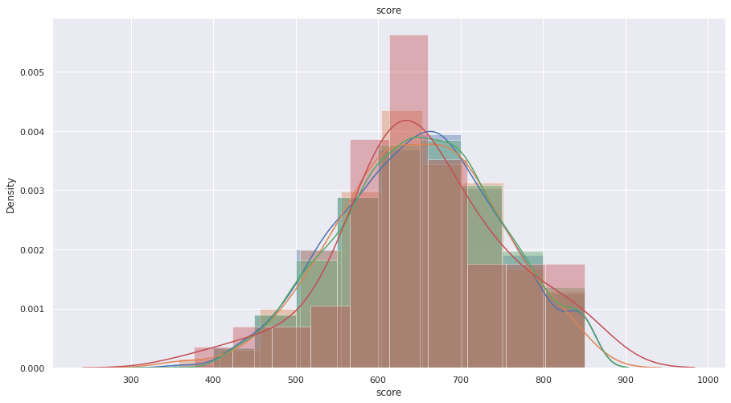

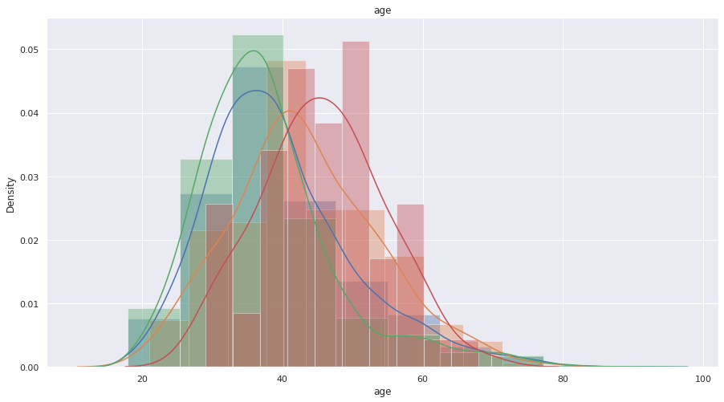

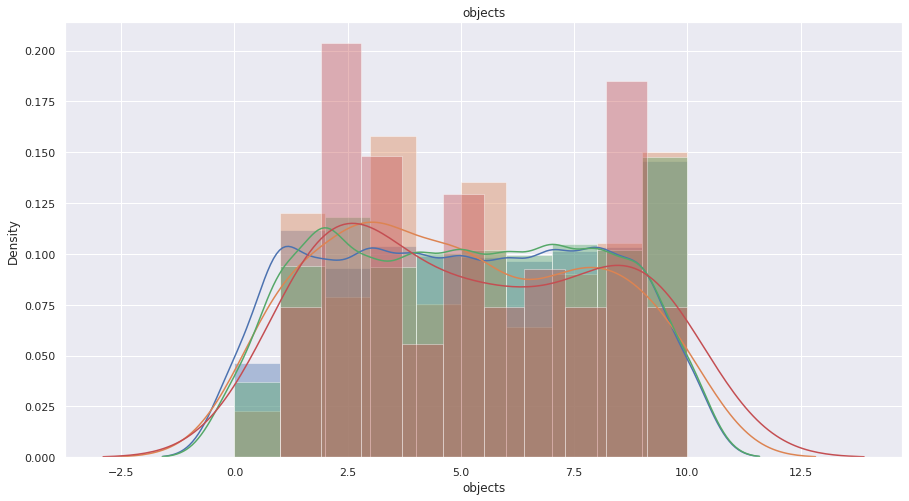

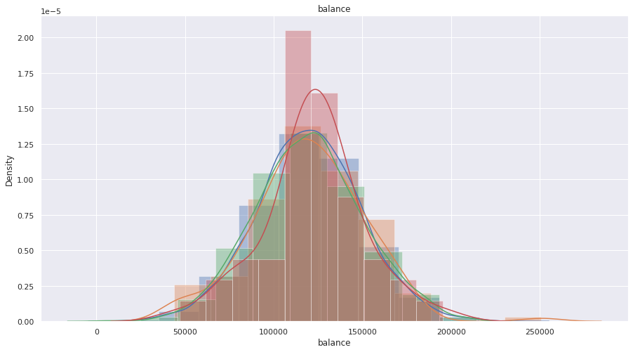

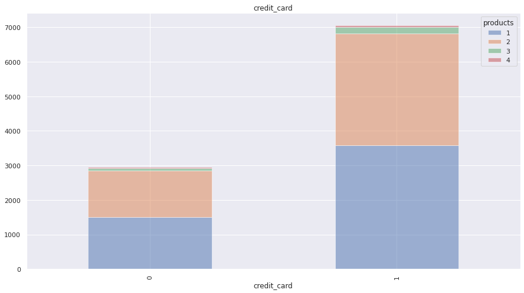

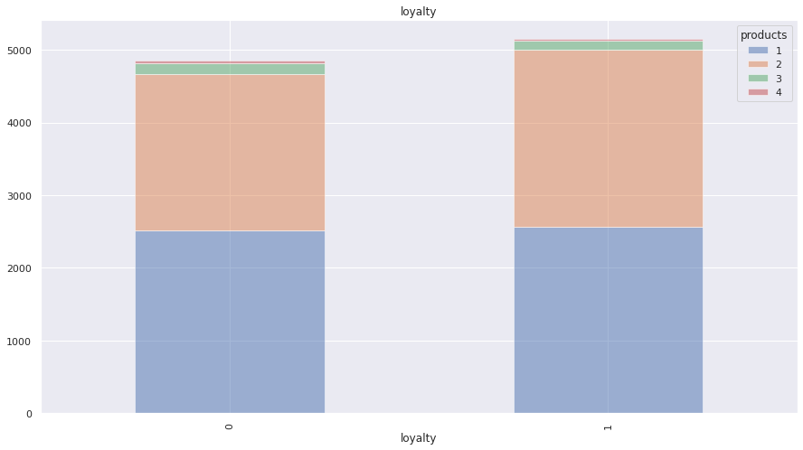

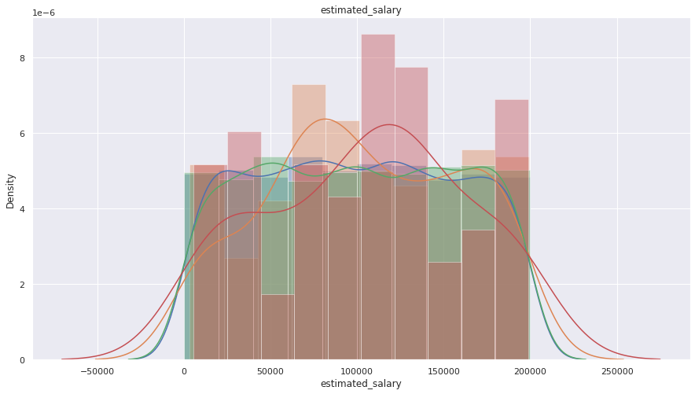

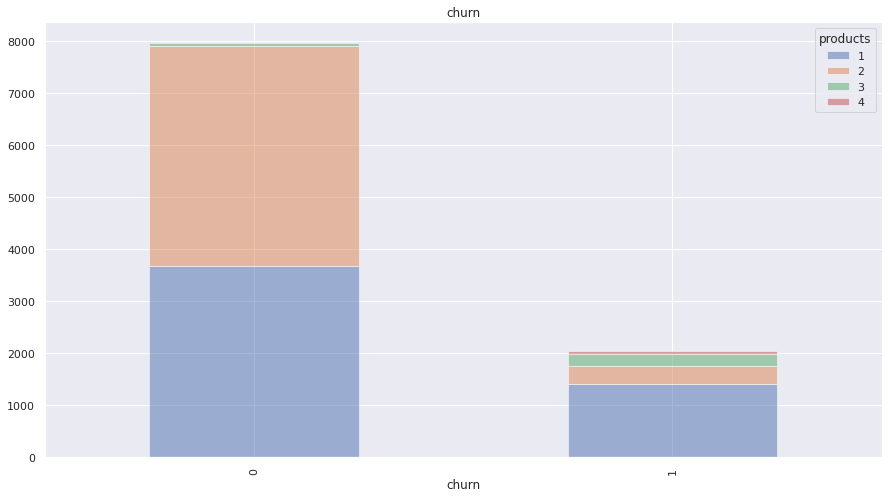

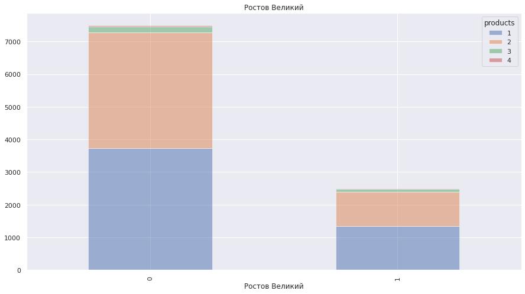

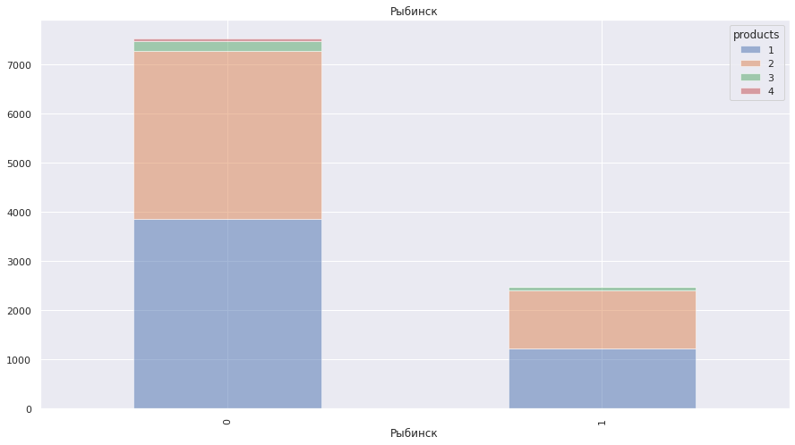

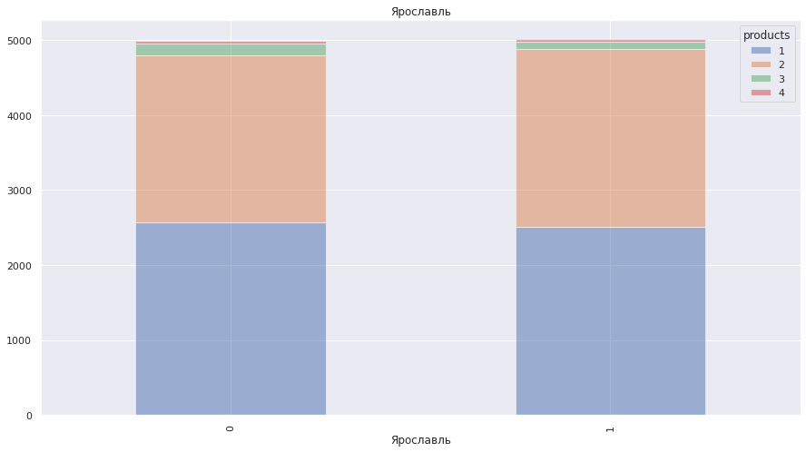

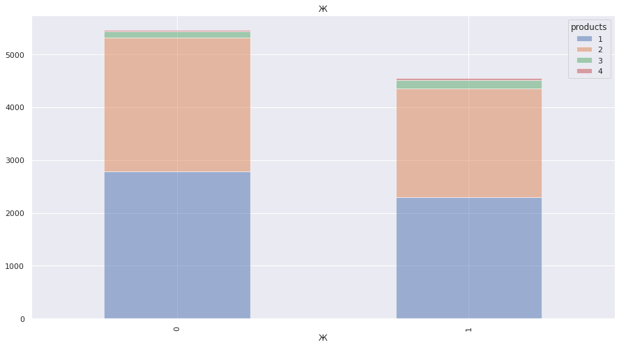

[1 more figures not shown]

```python
def graphics(data, group_col, name_col):
    data_part = data.copy()[name_col]
    for element_1 in name_col:
        if element_1 == group_col: continue

        if len(data_part[element_1].unique()) < 10:
            report = data_part.reset_index().pivot_table(index = element_1,
                                                         columns = group_col,
                                                         values = 'index',
                                                         aggfunc = 'count')
            report.plot(kind='bar',
                        stacked=True,
                        alpha = 0.5
                       )
        else:
            for element_2 in data[group_col].unique():
                sns.distplot(data_part[data_part[group_col] == element_2][element_1],
                             bins=10
                            )
        plt.title(element_1)
        plt.show()

graphics(data.drop('user_id', axis=1), 'products', data.drop('user_id', axis=1).columns);
```

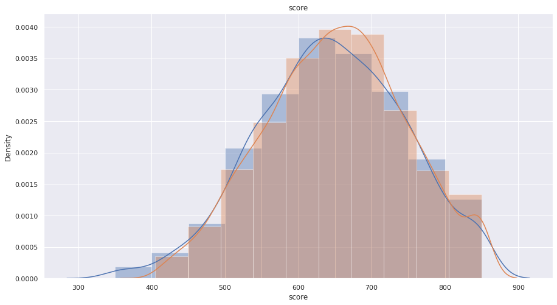

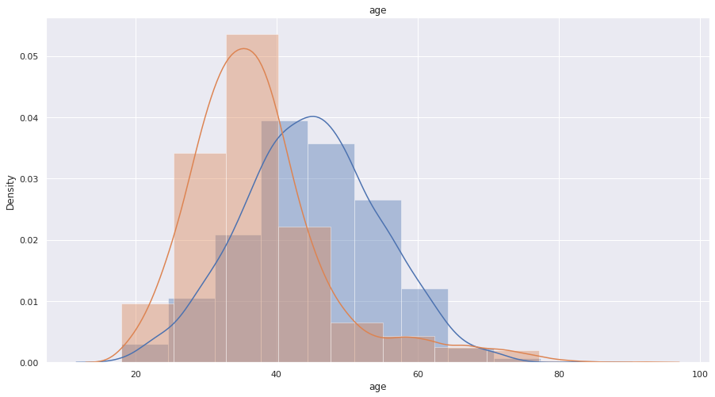

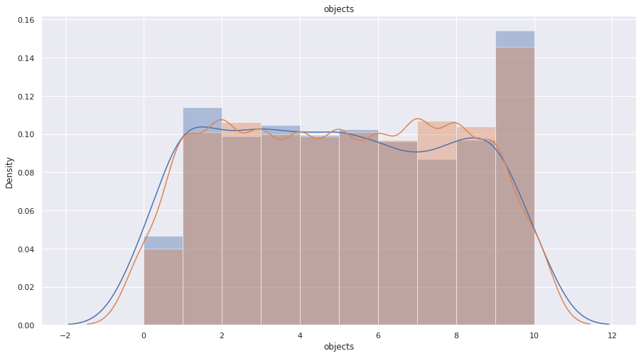

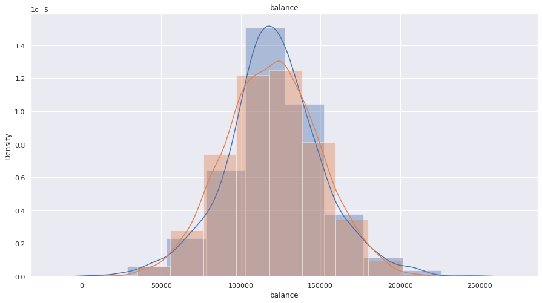

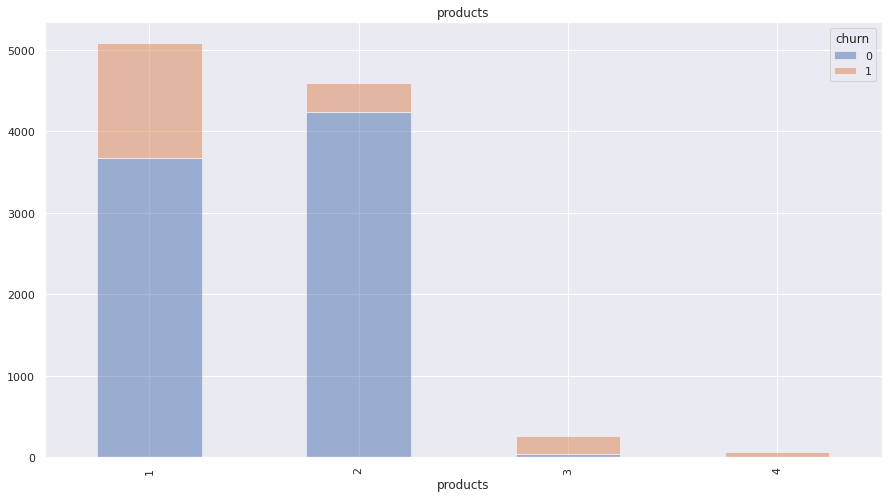

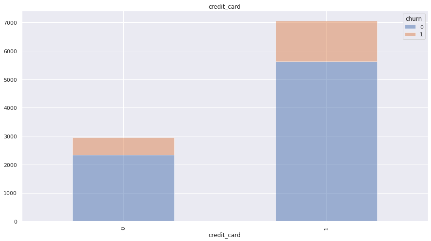

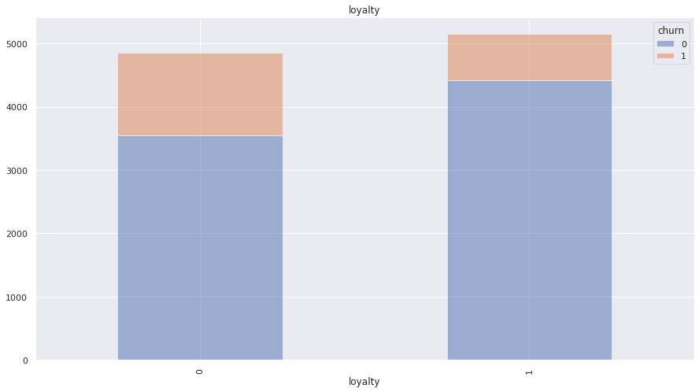

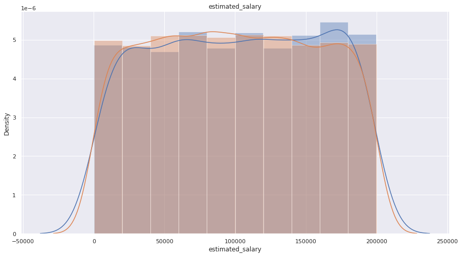

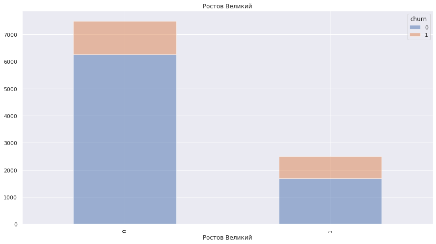

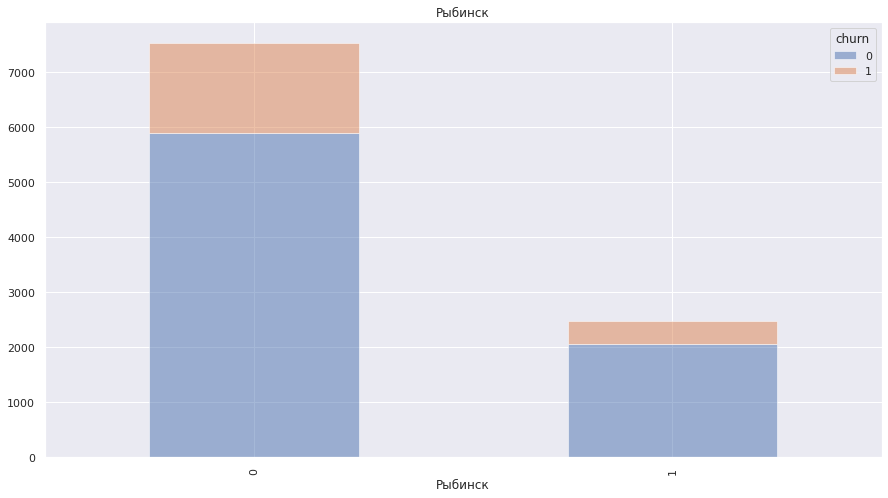

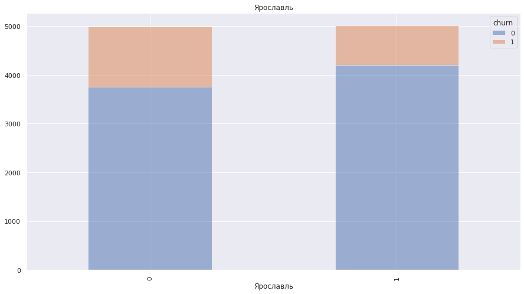

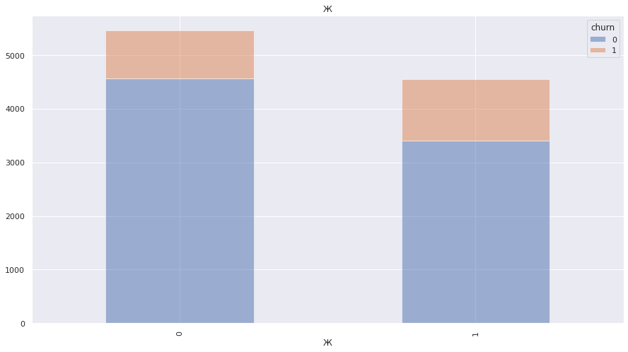

[1 more figures not shown]

```python
graphics(data.drop('user_id', axis=1), 'churn', data.drop('user_id', axis=1).columns);
```

По построенным графикам можно сделать следующие основные выводы:

- присутствует нарушение логики при построении зависимости отток /кол-во продуктов = 3 и 4, т.е. получается, что клиенты банка, имеющие 4 продукта все - в оттоке, хотя интуитивно понятно, что они должны являются активными участниками процесса;
- средний возраст владельцев 4 продуктов - выше, чем владельцев 1, 2 или 3 продуктов;
- сильный отток клиентов присутствует у клиентов, владеющих 1 банковским продуктом;
- минимален отток клиентов с 2 продуктами (в пропорции гораздо ниже, чем у клиентов с 1, 3 и 4).

### Построение матриц корреляции

Построю матрицу корреляции для признаков во всем датафрейме для выявления закономерностей.

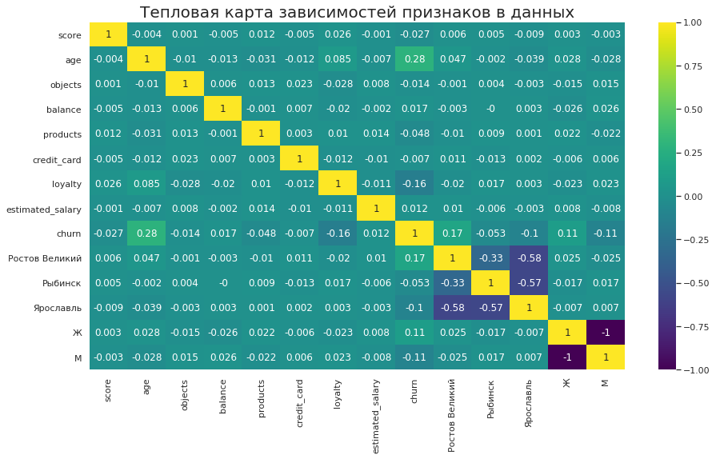

```python
cm = data.drop('user_id', axis=1).corr().round(3)

#построю тепловую карту с подписями для матрицы корреляций
sns.set(rc = {'figure.figsize':(15,8)})
sns.heatmap(cm, annot=True, cmap='viridis')
plt.title('Тепловая карта зависимостей признаков в данных', fontsize = 20)
plt.show();
```

Дополнительно посмотрю корреляцию отедльно по городам, может существуют какие-либо закономерности в зависимости от города:

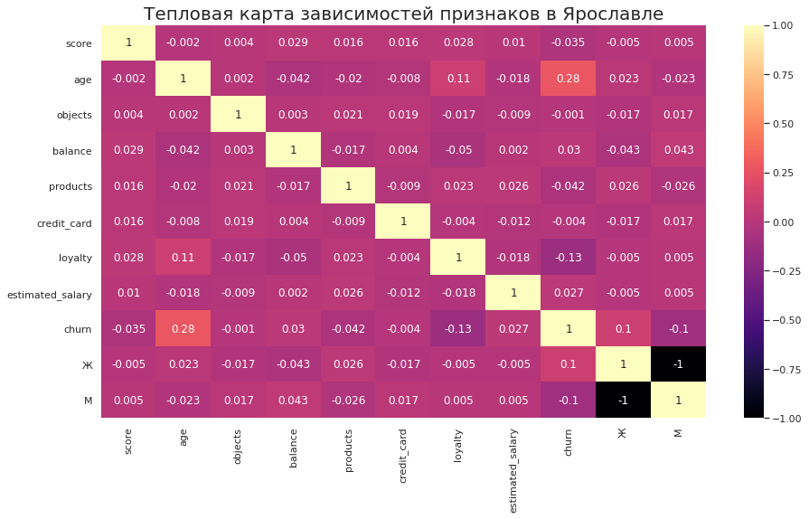

```python
data_yar = data.query('Ярославль == 1')
cm_yar = data_yar.drop(['user_id', 'Ярославль', 'Ростов Великий', 'Рыбинск'], axis=1).corr().round(3)

sns.set(rc = {'figure.figsize':(15,8)})
sns.heatmap(cm_yar, annot=True, cmap='magma')
plt.title('Тепловая карта зависимостей признаков в Ярославле', fontsize = 20)
plt.show();
```

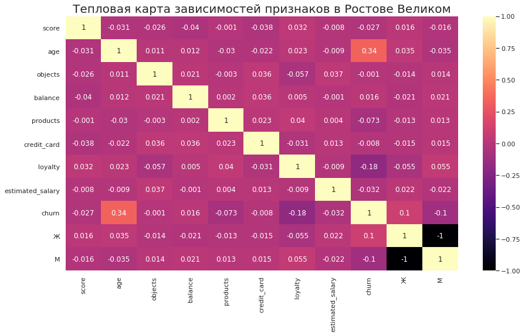

```python
data_rv = data.loc[data['Ростов Великий'] == 1]
cm_rv = data_rv.drop(['user_id', 'Ярославль', 'Ростов Великий', 'Рыбинск'], axis=1).corr().round(3)

sns.set(rc = {'figure.figsize':(15,8)})
sns.heatmap(cm_rv, annot=True, cmap='magma')
plt.title('Тепловая карта зависимостей признаков в Ростове Великом', fontsize = 20)
plt.show();
```

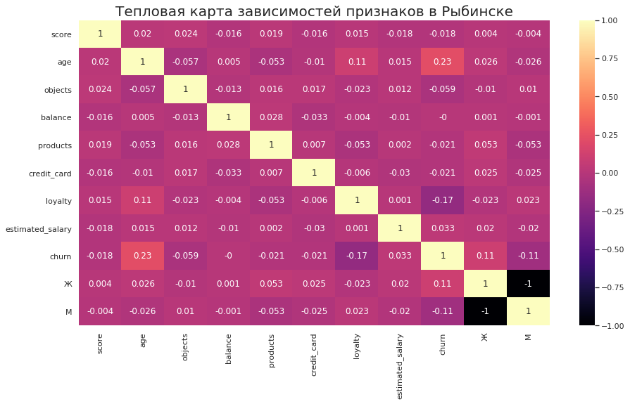

```python
data_ryb = data.query('Рыбинск == 1')
cm_ryb = data_ryb.drop(['user_id', 'Ярославль', 'Ростов Великий', 'Рыбинск'], axis=1).corr().round(3)

sns.set(rc = {'figure.figsize':(15,8)})
sns.heatmap(cm_ryb, annot=True, cmap='magma')
plt.title('Тепловая карта зависимостей признаков в Рыбинске', fontsize = 20)
plt.show();
```

В принципе, при построении матриц корреляции отдельно для городов, никаких явных выбросов не видно, однако можно обратить внимание, что в Ростове Великом возраст клиента влияет на отток сильнее, чем в других городах.

### Проведение кластеризации

В данном разделе буду проводить кластеризацию пользователей с учётом имеющихся в датафреме признаков, а именно, выделять несколько наиболее ярких групп и характеризовать их основные свойства для анализа основных признаков, наиболее сильно влияющих на отток в данных группах.

Создам датафрейм, соответствующий матрице вектор (тип Series) c целевой переменной `отток клиента - churn`. Проведу обязательную стандартизацию данных, построю матрицу расстояний функцией `linkage()` на стандартизованной матрице признаков и нарисую дендрограмму.

Для создания дендрограммы создам тестовый датафрейм с исключением данных с пропущенными значениями баланса, (с исключением созданных дамми-переменных и всех категориальных переменных).

```python
data_test = data
def cat_gender(param):
    if param == 1:
        return 'М'
    return 'Ж'

def cat_city(data_test):
    if data_test['Ярославль'] == 1:
        return 'Ярославль'
    if data_test['Рыбинск'] == 1:
        return 'Рыбинск'
    if data_test['Ростов Великий'] == 1:
        return 'Ростов Великий'

data_test['city'] = data_test.apply(cat_city, axis = 1)
data_test['gender'] = data_test['М'].apply(cat_gender)

encoder =  LabelEncoder()
data_test['city'] = encoder.fit_transform(data_test['city'])
data_test['gender'] = encoder.fit_transform(data_test['gender'])
data_test = data_test.drop(['Ростов Великий', 'Ярославль', 'Рыбинск', 'М', 'Ж'], axis=1)
data_test
```

|  | user_id | score | age | objects | balance | products | credit_card | loyalty | estimated_salary | churn | city | gender |
| --- | --- | --- | --- | --- | --- | --- | --- | --- | --- | --- | --- | --- |
| 0 | 15677338 | 619 | 42 | 2 | NaN | 1 | 1 | 1 | 101348.88 | 1 | 2 | 0 |
| 1 | 15690047 | 608 | 41 | 1 | 83807.86 | 1 | 0 | 1 | 112542.58 | 0 | 1 | 0 |
| 2 | 15662040 | 502 | 42 | 8 | 159660.80 | 3 | 1 | 0 | 113931.57 | 1 | 2 | 0 |
| 3 | 15744090 | 699 | 39 | 1 | NaN | 2 | 0 | 0 | 93826.63 | 0 | 2 | 0 |
| 4 | 15780624 | 850 | 43 | 2 | 125510.82 | 1 | 1 | 1 | 79084.10 | 0 | 1 | 0 |
| ... | ... | ... | ... | ... | ... | ... | ... | ... | ... | ... | ... | ... |
| 9995 | 15648965 | 771 | 39 | 5 | NaN | 2 | 1 | 0 | 96270.64 | 0 | 2 | 1 |
| 9996 | 15612628 | 516 | 35 | 10 | 57369.61 | 1 | 1 | 1 | 101699.77 | 0 | 2 | 1 |
| 9997 | 15627268 | 709 | 36 | 7 | NaN | 1 | 0 | 1 | 42085.58 | 1 | 2 | 0 |
| 9998 | 15725091 | 772 | 42 | 3 | 75075.31 | 2 | 1 | 0 | 92888.52 | 1 | 0 | 1 |
| 9999 | 15671055 | 792 | 28 | 4 | 130142.79 | 1 | 1 | 0 | 38190.78 | 0 | 2 | 0 |

10000 rows × 12 columns

При переводе категориальных переменных в количественные была проведена следующая замена:

- city: 0 - **Ростов Великий**
- city: 1 - **Рыбинск**
- city: 2 - **Ярославль**
- gender: 0 - **Ж**
- gender: 1 - **М**

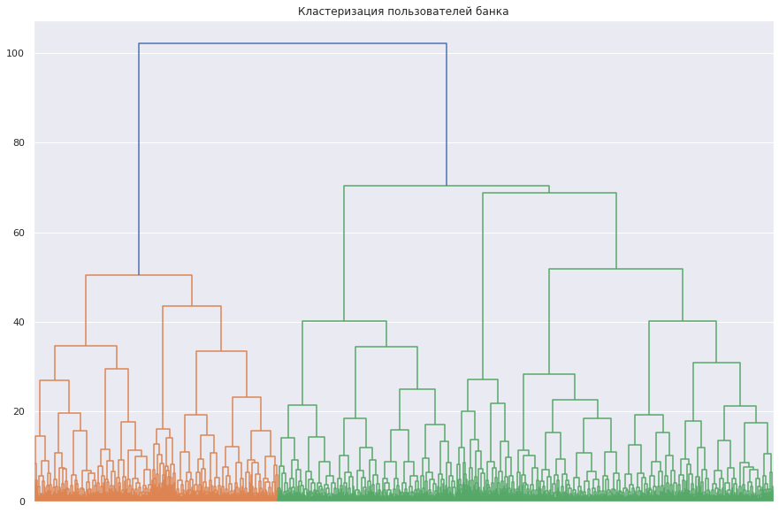

```python
data_test = data_test.dropna().drop(['user_id', 'city', 'gender', 'loyalty', 'credit_card', 'objects'], axis=1)

X = data_test.drop('churn', axis=1)

# обязательная стандартизация данных перед работой с алгоритмами
sc = StandardScaler()
X_sc = sc.fit_transform(X)

linked = linkage(X_sc, method = 'ward')

# визуализирую
plt.figure(figsize=(15, 10))
dendrogram(linked, orientation='top')
plt.title('Кластеризация пользователей банка')
plt.xticks([])
plt.show();
```

Предложенное оптимальное число кластеров 2 — два разных цвета на дендрограмме, однако заметно, что первый бьётся визуально на 2, а второй - на три, поэтому я выберу количество кластеров равное 5. Обучу модель кластеризации и рассчитаю средние значения признаков для каждого из кластеров для составления портрета пользователя из каждого кластера.

```python
# задаю число кластеров, равное 5, и фиксирую значение random_state для воспроизводимости результата
km = KMeans(n_clusters=5, random_state=0)

# применяю алгоритм к данным и формирую вектор кластеров
labels = km.fit_predict(X_sc)
data_test['labels'] = labels

# выведу статистику по средним значениям признаков по кластеру
display(data_test.groupby('labels').agg('mean').round(2))
```

| labels | score | age | balance | products | estimated_salary | churn |
| --- | --- | --- | --- | --- | --- | --- |
| 0 | 646.85 | 59.30 | 119271.18 | 1.23 | 92360.86 | 0.45 |
| 1 | 650.57 | 37.55 | 119615.13 | 2.18 | 129737.41 | 0.24 |
| 2 | 605.13 | 36.04 | 145257.77 | 1.21 | 55338.05 | 0.19 |
| 3 | 705.63 | 35.75 | 96766.17 | 1.26 | 54202.15 | 0.18 |
| 4 | 646.59 | 36.33 | 118336.45 | 1.00 | 155639.50 | 0.23 |

### Выводы по разделу

**Основные данные** исследуемой выборки:

- в выборке присутствуют пользователи обоих полов (мужчины и женщины) из 3 городов;
- средний возраст клиента - 39 лет, минимальный возраст - 18, максимальный - 92 года;
- баллы кредитного скоринга распределены в диапазоне 350 - 850;
- объектов собственности от 0 до 10;
- в среднем на балансе у клиента - около 120т.р., минимум 3800р., максимум 250т.р.;
- представленная выборка клиентов имеет от 1 до 4 банковских продуктов;
- кредитные карты есть у 70% клиентов;
- в выборке преобладают активные клиенты;
- средняя з/п клиента - 100т.р., минимум 12р., максимум - 200т.р., в выборке присутствуют аномальные значения.

Предварительные выводы при разделении клиентов на группы `в зависимости от количества банковских продуктов`:

- средний возраст клиентов, имеющих 3 и 4 продукта - выше, чем клиентов, имеющих 1 или 2 продукта;
- средний баланс на счетах вне зависимости от количества продуктов - примерно одинаков (около 120т.р.);
- клиенты банка, имеющие 4 продукта, со 100% вероятностью попадают в отток, владельцы 3 продуктов - с вероятностью 83%;
- с увеличением средней з/п клиента, увеличивается количество приобретённых продутов;
- кредитные карты есть у 70% клиентов, вне зависимости от того, сколько у него бансковских продуктов;
- активных клиентов - около половины, также не зависит от количества продуктов;
- в среднем клиент банка владеет 5 объектами в собственности;
- средняя кредитоспособность (баллы скоринга) не зависят от количества продуктов и в среднем составляют около 650;
- женщин, приобретающих 3 и 4 продута заметно больше, чем мужчин;
- мужчин с 1 или 2 кредитными продуктами - больше, чем женщин;
- в Ростове Великом и Ярославле клиентов, имеющих 3 или 4 банковских продукта явно больше, чем в Рыбинске;
- клиентов с 1 и 2 продуктами заметно больше в Ярославле, чем в Ростове и Рыбинске.

При разделении клиентов на группы `остался/попал в отток` и кластеризации получены следующие результаты:

Признаки, сильнее всего `влияющие на отток` клиентов:

- возраст клиента;
- активность клиента;
- проживание в Ростове Великом;
- пол клиента.

## Формулирование и проверка статистических гипотез

В этом разделе я буду проверять следующие гипотезы:

```
Гипотеза 1 - доход клиентов, пользующихся 1 и 2 банковскими продуктами, различаются;
Гипотеза 2 - у владельцев кредитных карточек и у тех, у кого кредиток нет, баллы скоринга различаются;
Гипотеза 3 - доля оттока мужчин и женщин в Ярославле различается;
Гипотеза 4 - доля оттока в Ростове Великом и в Ярославле различается;
Гипотеза 5 - количество денег на балансе влияет на получение статуса активности;
Гипотеза 6 - доля оттока у активных и неактивных пользователей различается;
Гипотеза 7 - уровень дохода в Ярославле и в других городах различается.
```

### Проверка Гипотезы 1

Для того, чтобы проверить, различается ли доход клиентов с 1 и 2 банковскими продуктами, необходимо сформулировать нулевую гипотезу, которую нужно подтвердить или отвергнуть в пользу альтернативной гипотезы. H₀ всегда формулируется так, чтобы использовать знак равенства, чтобы все данные лежали в районе изначально предполагаемого значения.

**Нулевая гипотеза H₀**:

- Средний доход пользователей 1 продукта и 2 продуктов одинаков

**Альтернативная гипотеза H₁**:

- Средний доход пользователей 1 продукта и 2 продуктов различается

```python
product_1 = data.query('products == 1')
product_2 = data.query('products == 2')

# Дополнительные данные для проверки использования тестов (дополнительная функция)
def input(data_1, data_2, value):
    print('Размер выборки 1 -', len(data_1))
    print('Размер выборки 2 -', len(data_2))
    print()
    print('Дисперсия выборки 1 -', round(data_1[value].var()))
    print('Дисперсия выборки 2 -', round(data_2[value].var()))

input(product_1, product_2, 'estimated_salary')
```

```
Размер выборки 1 - 5084
Размер выборки 2 - 4590

Дисперсия выборки 1 - 3290585635
Дисперсия выборки 2 - 3339776563
```

Т.к. в данном случае речь идет о проверке гипотезы о равенстве средних двух генеральных совокупностей, то я применю t-тест (метод `scipy.stats.ttest_ind`). Для применения t-теста необходимо выполнение 3 условий:

- генеральные совокупности не должны зависеть друг от друга - выполняется, т.к. мы рассматриваем 2 группы пользователей, использующих 1 или 2 банковских продукта - это независимые совокупности;
- выборочные средние должны быть нормально распределены. Это условие не препятствие. Размеры выборок достаточно велики (5084 и 4590 значений), поэтому выборочные средние, которые можно получить из одной и той же генеральной совокупности, будут распределены нормально вокруг истинного среднего этой совокупности. Это утверждение верно, даже если сама генеральная совокупность не распределена нормально.
- дисперсии рассматриваемых генеральных совокупностей должны быть равны. Выборки достаточно велики: симуляции, проведённые учёными, показывают, что даже если дисперсии на самом деле не равны, при большом объеме выборки выборочное среднее становится нормально распределенным и тест может быть применен.

Критический уровень статистической значимости я выберу 0.5%, т.к. мы имеем большие выборки, измеряемые тысячами наблюдений, поэтому уверенно отвергать нулевую гипотезу можно только при значимости меньшей 0,005.

```python
# Задаю критический уровень статистической значимости
alpha = 0.005
# если p-value окажется меньше alpha - отвегаю нулевую гипотезу

results = st.ttest_ind(
    product_1['estimated_salary'],
    product_2['estimated_salary'])
    #equal_var=False)

print('p-значение: ', results.pvalue)

if results.pvalue < alpha:
    print('Нулевая гипотеза отвергается')
else:
    print('Нулевая гипотеза не может быть отвергнута')
```

```
p-значение:  0.41047183624949335
Нулевая гипотеза не может быть отвергнута
```

Т.к. p-значение оказалось достаточно велико, выше критического уровня статистической значимости, то не могу отвергнуть нулевую гипотезу в пользу альтернативной и делаю вывод, что **разницы в среднем доходе у пользователей 1 и 2 банковских продуктов нет**.

### Проверка Гипотезы 2

**Нулевая гипотеза H₀**:

- Среднее количество баллов кредитного скоринга у владельцев кредитных карт и у тех, у кого их нет, одинаков

**Альтернативная гипотеза H₁**:

- Среднее количество баллов кредитного скоринга у владельцев кредитных карт и у тех, у кого их нет, различается

```python
credit_0 = data.query('credit_card == 0')
credit_1 = data.query('credit_card == 1')

input(credit_0, credit_1, 'score')
```

```
Размер выборки 1 - 2945
Размер выборки 2 - 7055

Дисперсия выборки 1 - 9339
Дисперсия выборки 2 - 9344
```

Параметры выборок подходят для сравнения средних двух генеральных совокупностей между собой. Буду использовать t-тест.

```python
alpha = 0.005
results = st.ttest_ind(
    credit_0['score'],
    credit_1['score'])
print('p-значение: ', results.pvalue)

if results.pvalue < alpha:
    print('Нулевая гипотеза отвергается')
else:
    print('Нулевая гипотеза не может быть отвергнута')
```

```
p-значение:  0.5852143953187045
Нулевая гипотеза не может быть отвергнута
```

Т.к. p-значение оказалось достаточно велико, выше критического уровня статистической значимости, то не могу отвергнуть нулевую гипотезу в пользу альтернативной и делаю вывод, что **разницы в баллах кредитного скоринга у пользователей, имеющих и не имеющих кредитки, нет**.

### Проверка Гипотезы 3

**Нулевая гипотеза H₀**:

- доля оттока мужчин и женщин в Ярославле одинакова

**Альтернативная гипотеза H₁**:

- доля оттока мужчин и женщин в Ярославле разная

Т.к. при проверке данной гипотезы я буду сравнивать доли мужчин и женщин, попавших в отток, т.е. буду сравнивать пропорции двух генеральных совокупностей по выборкам из них, то я буду использовать z-тест.

Для начала рассчитаю, какое количество женщин и мужчин попало в отток в Ярославле:

```python
data_yar = data.query('Ярославль == 1')
m = len(data_yar.query('М == 1'))
f = len(data_yar.query('Ж == 1'))
m_ch = len(data_yar.query('М == 1 and churn == 1'))
f_ch = len(data_yar.query('Ж == 1 and churn == 1'))
print('Количество клиентов мужчин в Ярославле:', m)
print('Количество клиентов женщин Ярославле:', f)
print('Отток мужчин:', m_ch)
print('Отток женщин:', f_ch)
print()
print('Процент оттока мужчин: {:.2%}'.format(m_ch / m))
print('Процент оттока женщин: {:.2%}'.format(f_ch / f))
```

```
Количество клиентов мужчин в Ярославле: 2753
Количество клиентов женщин Ярославле: 2261
Отток мужчин: 350
Отток женщин: 460

Процент оттока мужчин: 12.71%
Процент оттока женщин: 20.34%
```

```python
alpha = 0.05  # критический уровень статистической значимости

purchases = np.array([350, 460])
leads = np.array([2753, 2261])

p1 = purchases[0]/leads[0]
p2 = purchases[1]/leads[1]
p_combined = (purchases[0] + purchases[1]) / (leads[0] + leads[1])
difference = p1 - p2

z_value = difference / mth.sqrt(p_combined * (1 - p_combined) * (1/leads[0] + 1/leads[1]))

distr = st.norm(0, 1)

p_value = (1 - distr.cdf(abs(z_value))) * 2

print('p-значение: ', p_value)

if p_value < alpha:
    print('Отвергаем нулевую гипотезу: между долями есть значимая разница')
else:
    print(
        'Не получилось отвергнуть нулевую гипотезу, нет оснований считать доли разными'
    )
```

```
p-значение:  2.7489122089718876e-13
Отвергаем нулевую гипотезу: между долями есть значимая разница
```

Такая разница в пропорциях при указанных размерах выборок достаточна, чтобы говорить о статистически значимом **различии между оттоком мужчин и женщин в Ярославле**. А именно, женщины в Ярославле чаще перестают пользоваться услугами банка.

### Проверка Гипотезы 4

**Нулевая гипотеза H₀**:

- отток клиентов в Ярославле и в Ростове Великом одинаков

**Альтернативная гипотеза H₁**:

- отток клиентов в Ярославле и в Ростове Великом различается

Также речь идёт о сравнении пропорций двух генеральных совокупностей по выборкам из них, поэтому я снова буду использовать z-тест.

Для начала рассчитаю, какое количество клиентов в разных городах попало в отток:

```python
yar = len(data.query('Ярославль == 1'))

# query() не позволяет работать с именами столбцов с пробелами
rv = len(data.loc[data['Ростов Великий'] == 1])

yar_ch = len(data.query('Ярославль == 1 and churn == 1'))
rv_ch = len(data.loc[(data['Ростов Великий'] == 1) & (data['churn'] == 1)])
print('Количество клиентов в Ярославле:', yar)
print('Количество клиентов в Ростове Великом:', rv)
print('Отток ярославцев:', yar_ch)
print('Отток ростовчан:', rv_ch)
print()
print('Процент оттока ярославцев: {:.2%}'.format(yar_ch / yar))
print('Процент оттока ростовчан: {:.2%}'.format(rv_ch / rv))
```

```
Количество клиентов в Ярославле: 5014
Количество клиентов в Ростове Великом: 2509
Отток ярославцев: 810
Отток ростовчан: 814

Процент оттока ярославцев: 16.15%
Процент оттока ростовчан: 32.44%
```

```python
alpha = 0.05  # критический уровень статистической значимости

purchases = np.array([810, 814])
leads = np.array([5014, 2509])

p1 = purchases[0]/leads[0]
p2 = purchases[1]/leads[1]
p_combined = (purchases[0] + purchases[1]) / (leads[0] + leads[1])
difference = p1 - p2

z_value = difference / mth.sqrt(p_combined * (1 - p_combined) * (1/leads[0] + 1/leads[1]))

distr = st.norm(0, 1)

p_value = (1 - distr.cdf(abs(z_value))) * 2

print('p-значение: ', p_value)

if p_value < alpha:
    print('Отвергаем нулевую гипотезу: между долями есть значимая разница')
else:
    print(
        'Не получилось отвергнуть нулевую гипотезу, нет оснований считать доли разными'
    )
```

```
p-значение:  0.0
Отвергаем нулевую гипотезу: между долями есть значимая разница
```

Очень большая разница в пропорциях при указанных размерах выборок достаточна, чтобы говорить о статистически значимом **различии между оттоком клиентов в Ярославле и Ростове Великом**.

### Проверка Гипотезы 5

**Нулевая гипотеза H₀**:

- средний баланс у активных и неактивных пользователей одинаков

**Альтернативная гипотеза H₁**:

- средний баланс у активных и неактивных пользователей различается

```python
loyalty_0 = data.query('loyalty == 0')
loyalty_1 = data.query('loyalty == 1')

input(loyalty_0, loyalty_1, 'balance')
```

```
Размер выборки 1 - 4849
Размер выборки 2 - 5151

Дисперсия выборки 1 - 889335051
Дисперсия выборки 2 - 920766241
```

Параметры выборок подходят для сравнения средних двух генеральных совокупностей между собой. Буду использовать t-тест.

```python
alpha = 0.005
results = st.ttest_ind(
    loyalty_0['balance'],
    loyalty_1['balance'])
print('p-значение: ', results.pvalue)

if results.pvalue < alpha:
    print('Нулевая гипотеза отвергается')
else:
    print('Нулевая гипотеза не может быть отвергнута')
```

```
p-значение:  nan
Нулевая гипотеза не может быть отвергнута
```

### Проверка Гипотезы 6

**Нулевая гипотеза H₀**:

- отток активных и неактивных клиентов одинаков

**Альтернативная гипотеза H₁**:

- отток активных и неактивных клиентов различается

Здесь речь идёт о сравнении пропорций двух генеральных совокупностей по выборкам из них, поэтому я снова буду использовать z-тест.

Для начала рассчитаю, какое количество активных и неактивных клиентов попало в отток:

```python
lo = len(data.query('loyalty == 1'))
nlo = len(data.query('loyalty == 0'))
lo_ch = len(data.query('loyalty == 1 and churn == 1'))
nlo_ch = len(data.query('loyalty == 0 and churn == 1'))
print('Количество активных клиентов:', lo)
print('Количество неактивных клиентов:', nlo)
print('Отток активных клиентов:', lo_ch)
print('Отток неактивных клиентов:', nlo_ch)
print()
print('Процент оттока активных клиентов: {:.2%}'.format(lo_ch / lo))
print('Процент оттока неактивных клиентов: {:.2%}'.format(nlo_ch / nlo))
```

```
Количество активных клиентов: 5151
Количество неактивных клиентов: 4849
Отток активных клиентов: 735
Отток неактивных клиентов: 1302

Процент оттока активных клиентов: 14.27%
Процент оттока неактивных клиентов: 26.85%
```

```python
alpha = 0.05  # критический уровень статистической значимости

purchases = np.array([735, 1302])
leads = np.array([5151, 4849])

p1 = purchases[0]/leads[0]
p2 = purchases[1]/leads[1]
p_combined = (purchases[0] + purchases[1]) / (leads[0] + leads[1])
difference = p1 - p2

z_value = difference / mth.sqrt(p_combined * (1 - p_combined) * (1/leads[0] + 1/leads[1]))

distr = st.norm(0, 1)

p_value = (1 - distr.cdf(abs(z_value))) * 2

print('p-значение: ', p_value)

if p_value < alpha:
    print('Отвергаем нулевую гипотезу: между долями есть значимая разница')
else:
    print(
        'Не получилось отвергнуть нулевую гипотезу, нет оснований считать доли разными'
    )
```

```
p-значение:  0.0
Отвергаем нулевую гипотезу: между долями есть значимая разница
```

Очень большая разница в пропорциях при указанных размерах выборок достаточна, чтобы говорить о статистически значимом **различии между оттоком активных и неактивных клиетов**.

### Проверка Гипотезы 7

**Нулевая гипотеза H₀**:

- доход клиентов в Ярославле и в других городах одинаков

**Альтернативная гипотеза H₁**:

- доход клиентов в Ярославле и в других городах различается

```python
data_yar = data.query('Ярославль == 1')
data_r = data.query('Ярославль == 0')

# Дополнительные данные для проверки использования тестов (дополнительная функция)
def input(data_1, data_2, value):
    print('Размер выборки 1 -', len(data_yar))
    print('Размер выборки 2 -', len(data_r))
    print()
    print('Дисперсия выборки 1 -', round(data_yar[value].var()))
    print('Дисперсия выборки 2 -', round(data_r[value].var()))

input(data_yar, data_r, 'estimated_salary')
```

```
Размер выборки 1 - 5014
Размер выборки 2 - 4986

Дисперсия выборки 1 - 3287450038
Дисперсия выборки 2 - 3328165749
```

Т.к. в данном случае речь идет о проверке гипотезы о равенстве средних двух генеральных совокупностей, то я применю t-тест (метод `scipy.stats.ttest_ind`).

Критический уровень статистической значимости я выберу 0.5%, т.к. мы имеем большие выборки, измеряемые тысячами наблюдений, поэтому уверенно отвергать нулевую гипотезу можно только при значимости меньшей 0,005.

```python
# Задаю критический уровень статистической значимости
alpha = 0.005
# если p-value окажется меньше alpha - отвегаю нулевую гипотезу

results = st.ttest_ind(
    data_yar['estimated_salary'],
    data_r['estimated_salary'])
    #equal_var=False)

print('p-значение: ', results.pvalue)

if results.pvalue < alpha:
    print('Нулевая гипотеза отвергается')
else:
    print('Нулевая гипотеза не может быть отвергнута')
```

```
p-значение:  0.7390410907921137
Нулевая гипотеза не может быть отвергнута
```

Т.к. p-значение оказалось достаточно велико, выше критического уровня статистической значимости, то не могу отвергнуть нулевую гипотезу в пользу альтернативной и делаю вывод, что **разницы в среднем доходе у пользователей в Ярославле, Рыбинске и Ростове Великом нет**.

## Выводы и рекомендации

При разделении клиентов на группы `в зависимости от количества банковских продуктов` получены следующие результаты:

- средний возраст клиентов, имеющих 3 и 4 продукта - выше, чем клиентов, имеющих 1 или 2 продукта;
- средний баланс на счетах вне зависимости от количества продуктов - примерно одинаков (около 120т.р.);
- клиенты банка, имеющие 4 продукта, со 100% вероятностью попадают в отток, владельцы 3 продуктов - с вероятностью 83%;
- с увеличением средней з/п клиента, увеличивается количество приобретённых продутов;
- кредитные карты есть у 70% клиентов, вне зависимости от того, сколько у него бансковских продуктов;
- активных клиентов - около половины, также не зависит от количества продуктов;
- в среднем клиент банка владеет 5 объектами в собственности;
- средняя кредитоспособность (баллы скоринга) не зависят от количества продуктов и в среднем составляют около 650;
- женщин, приобретающих 3 и 4 продута заметно больше, чем мужчин;
- мужчин с 1 или 2 кредитными продуктами - больше, чем женщин;
- в Ростове Великом и Ярославле клиентов, имеющих 3 или 4 банковских продукта явно больше, чем в Рыбинске;
- клиентов с 1 и 2 продуктами заметно больше в Ярославле, чем в Ростове и Рыбинске.

При разделении клиентов на группы `остался/попал в отток` получены следующие результаты:

Признаки, сильнее всего `влияющие на отток` клиентов:

- возраст клиента;
- активность клиента;
- проживание в Ростове Великом;
- пол клиента.

**Для уменьшения оттока клиентов из банка предлагаю к рассмотрению следующие рекомендации:**

```
- делать значительные скидки на второй продукт;
- проводить мероприятия по увеличению активности клиентов (особое внимание - Ростов Великий);
- применять в Рыбинске и Ростове Великом похожие акции, что и в Ярославле, т.к. уровень дохода в городах примерно равный, а отток в Ярославле меньше всего;
- для удержания лиц женского пола и клиентов в возрасте (>50 лет), предлагать им выгодные условия и дарить подарки.
```

## Ссылки на дашборд и презентацию

**Дашборд** можно посмотреть по ссылке: https://public.tableau.com/app/profile/nataliya2772/viz/Dash_KotsNS_bank/Dashboard1?publish=yes

**Презентация**: https://disk.yandex.ru/i/CXGNnW9KtEiTnw